# VGK-Project6-FMT

## Data Description:

The actual concrete compressive strength (MPa) for a given mixture under a specific age (days) was determined from laboratory. Data is in raw form (not scaled).The data has 8 quantitative input variables, and 1 quantitative output variable, and 1030 instances (observations).

## Domain:

Material manufacturing

## Context:

Concrete is the most important material in civil engineering. The concrete compressive strength is a highly nonlinear function of age and ingredients. These ingredients include cement, blast furnace slag, fly ash, water, superplasticizer, coarse aggregate, and fine aggregate.

## Attribute Information:

- Cement : measured in kg in a m3 mixture
- Blast : measured in kg in a m3 mixture
- Fly ash : measured in kg in a m3 mixture
- Water : measured in kg in a m3 mixture
- Superplasticizer : measured in kg in a m3 mixture
- Coarse Aggregate : measured in kg in a m3 mixture
- Fine Aggregate : measured in kg in a m3 mixture
- Age : day (1~365)
- Concrete compressive strength measured in MPa

## Learning Outcomes:

- Exploratory Data Analysis
- Building ML models for regression
- Hyper parameter tuning

## Objective:

Modeling of strength of high performance concrete using Machine Learning

#### Domain specific links referred to --

https://www.nevadareadymix.com/concrete-tips/testing-the-compressive-strength-of-concrete/

#### Further reference

https://medium.com/fintechexplained/how-to-fine-tune-your-machine-learning-models-to-improve-forecasting-accuracy-e18e67e58898

```python
%matplotlib inline
import pandas as pd
import numpy as np
from matplotlib import pyplot as plt
import seaborn as sns
```

```python
concrete_df = pd.read_csv('concrete.csv')
concrete_df.head(100)
```

|  | cement | slag | ash | water | superplastic | coarseagg | fineagg | age | strength |
| --- | --- | --- | --- | --- | --- | --- | --- | --- | --- |
| 0 | 141.3 | 212.0 | 0.0 | 203.5 | 0.0 | 971.8 | 748.5 | 28 | 29.89 |
| 1 | 168.9 | 42.2 | 124.3 | 158.3 | 10.8 | 1080.8 | 796.2 | 14 | 23.51 |
| 2 | 250.0 | 0.0 | 95.7 | 187.4 | 5.5 | 956.9 | 861.2 | 28 | 29.22 |
| 3 | 266.0 | 114.0 | 0.0 | 228.0 | 0.0 | 932.0 | 670.0 | 28 | 45.85 |
| 4 | 154.8 | 183.4 | 0.0 | 193.3 | 9.1 | 1047.4 | 696.7 | 28 | 18.29 |
| 5 | 255.0 | 0.0 | 0.0 | 192.0 | 0.0 | 889.8 | 945.0 | 90 | 21.86 |
| 6 | 166.8 | 250.2 | 0.0 | 203.5 | 0.0 | 975.6 | 692.6 | 7 | 15.75 |
| 7 | 251.4 | 0.0 | 118.3 | 188.5 | 6.4 | 1028.4 | 757.7 | 56 | 36.64 |
| 8 | 296.0 | 0.0 | 0.0 | 192.0 | 0.0 | 1085.0 | 765.0 | 28 | 21.65 |
| 9 | 155.0 | 184.0 | 143.0 | 194.0 | 9.0 | 880.0 | 699.0 | 28 | 28.99 |
| 10 | 151.8 | 178.1 | 138.7 | 167.5 | 18.3 | 944.0 | 694.6 | 28 | 36.35 |
| 11 | 173.0 | 116.0 | 0.0 | 192.0 | 0.0 | 946.8 | 856.8 | 3 | 6.94 |
| 12 | 385.0 | 0.0 | 0.0 | 186.0 | 0.0 | 966.0 | 763.0 | 14 | 27.92 |
| 13 | 237.5 | 237.5 | 0.0 | 228.0 | 0.0 | 932.0 | 594.0 | 7 | 26.26 |
| 14 | 167.0 | 187.0 | 195.0 | 185.0 | 7.0 | 898.0 | 636.0 | 28 | 23.89 |
| 15 | 213.8 | 98.1 | 24.5 | 181.7 | 6.7 | 1066.0 | 785.5 | 100 | 49.97 |
| 16 | 237.5 | 237.5 | 0.0 | 228.0 | 0.0 | 932.0 | 594.0 | 28 | 30.08 |
| 17 | 336.0 | 0.0 | 0.0 | 182.0 | 3.0 | 986.0 | 817.0 | 28 | 44.86 |
| 18 | 190.7 | 0.0 | 125.4 | 162.1 | 7.8 | 1090.0 | 804.0 | 3 | 15.04 |
| 19 | 312.7 | 0.0 | 0.0 | 178.1 | 8.0 | 999.7 | 822.2 | 28 | 25.10 |
| 20 | 229.7 | 0.0 | 118.2 | 195.2 | 6.1 | 1028.1 | 757.6 | 3 | 13.36 |
| 21 | 228.0 | 342.1 | 0.0 | 185.7 | 0.0 | 955.8 | 674.3 | 7 | 21.92 |
| 22 | 236.0 | 157.0 | 0.0 | 192.0 | 0.0 | 972.6 | 749.1 | 7 | 20.42 |
| 23 | 132.0 | 207.0 | 161.0 | 179.0 | 5.0 | 867.0 | 736.0 | 28 | 33.30 |
| 24 | 331.0 | 0.0 | 0.0 | 192.0 | 0.0 | 1025.0 | 821.0 | 28 | 31.74 |
| 25 | 310.0 | 143.0 | 0.0 | 168.0 | 10.0 | 914.0 | 804.0 | 28 | 45.30 |
| 26 | 304.0 | 76.0 | 0.0 | 228.0 | 0.0 | 932.0 | 670.0 | 90 | 49.19 |
| 27 | 425.0 | 106.3 | 0.0 | 153.5 | 16.5 | 852.1 | 887.1 | 91 | 65.20 |
| 28 | 166.1 | 0.0 | 163.3 | 176.5 | 4.5 | 1058.6 | 780.1 | 28 | 21.54 |
| 29 | 255.0 | 99.0 | 77.0 | 189.0 | 6.0 | 919.0 | 749.0 | 28 | 33.80 |
| ... | ... | ... | ... | ... | ... | ... | ... | ... | ... |
| 70 | 200.0 | 133.0 | 0.0 | 192.0 | 0.0 | 965.4 | 806.2 | 3 | 11.41 |
| 71 | 342.0 | 38.0 | 0.0 | 228.0 | 0.0 | 932.0 | 670.0 | 90 | 50.46 |
| 72 | 388.6 | 97.1 | 0.0 | 157.9 | 12.1 | 852.1 | 925.7 | 3 | 28.10 |
| 73 | 147.8 | 175.1 | 0.0 | 171.2 | 2.2 | 1000.0 | 828.5 | 28 | 26.92 |
| 74 | 290.4 | 0.0 | 96.2 | 168.1 | 9.4 | 961.2 | 865.0 | 56 | 45.08 |
| 75 | 500.0 | 0.0 | 0.0 | 200.0 | 0.0 | 1125.0 | 613.0 | 14 | 36.94 |
| 76 | 284.0 | 15.0 | 141.0 | 179.0 | 5.5 | 842.0 | 801.0 | 7 | 24.13 |
| 77 | 165.0 | 128.5 | 132.1 | 175.1 | 8.1 | 1005.8 | 746.6 | 3 | 19.42 |
| 78 | 218.2 | 54.6 | 123.8 | 140.8 | 11.9 | 1075.7 | 792.7 | 3 | 27.42 |
| 79 | 168.9 | 42.2 | 124.3 | 158.3 | 10.8 | 1080.8 | 796.2 | 56 | 39.15 |
| 80 | 190.3 | 0.0 | 125.2 | 161.9 | 9.9 | 1088.1 | 802.6 | 28 | 28.47 |
| 81 | 116.0 | 173.0 | 0.0 | 192.0 | 0.0 | 909.8 | 891.9 | 90 | 31.02 |
| 82 | 277.0 | 0.0 | 0.0 | 191.0 | 0.0 | 968.0 | 856.0 | 90 | 31.25 |
| 83 | 376.0 | 0.0 | 0.0 | 214.6 | 0.0 | 1003.5 | 762.4 | 100 | 43.06 |
| 84 | 236.0 | 0.0 | 0.0 | 194.0 | 0.0 | 968.0 | 885.0 | 14 | 12.84 |
| 85 | 273.0 | 0.0 | 90.0 | 199.0 | 11.0 | 931.0 | 762.0 | 28 | 32.24 |
| 86 | 500.0 | 0.0 | 0.0 | 140.0 | 4.0 | 966.0 | 853.0 | 28 | 67.57 |
| 87 | 212.5 | 0.0 | 100.4 | 159.3 | 8.7 | 1007.8 | 903.6 | 14 | 26.31 |
| 88 | 362.6 | 189.0 | 0.0 | 164.9 | 11.6 | 944.7 | 755.8 | 3 | 35.30 |
| 89 | 275.1 | 0.0 | 121.4 | 159.5 | 9.9 | 1053.6 | 777.5 | 3 | 23.80 |
| 90 | 139.6 | 209.4 | 0.0 | 192.0 | 0.0 | 1047.0 | 806.9 | 7 | 14.59 |
| 91 | 362.6 | 189.0 | 0.0 | 164.9 | 11.6 | 944.7 | 755.8 | 7 | 55.90 |
| 92 | 182.0 | 45.2 | 122.0 | 170.2 | 8.2 | 1059.4 | 780.7 | 14 | 21.50 |
| 93 | 427.5 | 47.5 | 0.0 | 228.0 | 0.0 | 932.0 | 594.0 | 180 | 41.84 |
| 94 | 183.9 | 122.6 | 0.0 | 203.5 | 0.0 | 959.2 | 800.0 | 3 | 4.90 |
| 95 | 475.0 | 0.0 | 59.0 | 142.0 | 1.9 | 1098.0 | 641.0 | 28 | 57.23 |
| 96 | 362.6 | 189.0 | 0.0 | 164.9 | 11.6 | 944.7 | 755.8 | 28 | 71.30 |
| 97 | 318.8 | 212.5 | 0.0 | 155.7 | 14.3 | 852.1 | 880.4 | 7 | 33.40 |
| 98 | 252.0 | 97.0 | 76.0 | 194.0 | 8.0 | 835.0 | 821.0 | 28 | 33.40 |
| 99 | 237.5 | 237.5 | 0.0 | 228.0 | 0.0 | 932.0 | 594.0 | 180 | 36.25 |

100 rows × 9 columns

```python
concrete_df.shape
```

```
(1030, 9)
```

```python
concrete_df.isna().sum()
```

```
cement          0
slag            0
ash             0
water           0
superplastic    0
coarseagg       0
fineagg         0
age             0
strength        0
dtype: int64
```

## Observation ::

- I do see lot of 0s in Slag, Ash, Superplastic. We are not sure this is valid or mistyped.
- The data desc for second column says blast, but the CSV says slag
- By M3 mixture i guess is cubic meter ?
- No invalid values

## Deliverable -1 (Exploratory data quality report reflecting the following)

### a. Univariate analysis

i. Univariate analysis – data types and description of the independent attributes which should include name, meaning, range of values observed, central values (mean and median), standard deviation and quartiles, analysis of the body of distributions / tails, missing values, outliers

```python
concrete_df.info()
```

```
<class 'pandas.core.frame.DataFrame'>
RangeIndex: 1030 entries, 0 to 1029
Data columns (total 9 columns):
cement          1030 non-null float64
slag            1030 non-null float64
ash             1030 non-null float64
water           1030 non-null float64
superplastic    1030 non-null float64
coarseagg       1030 non-null float64
fineagg         1030 non-null float64
age             1030 non-null int64
strength        1030 non-null float64
dtypes: float64(8), int64(1)
memory usage: 72.5 KB
```

#### All are numbers, no object so we are good.

```python
concrete_df.describe().transpose()
```

|  | count | mean | std | min | 25% | 50% | 75% | max |
| --- | --- | --- | --- | --- | --- | --- | --- | --- |
| cement | 1030.0 | 281.167864 | 104.506364 | 102.00 | 192.375 | 272.900 | 350.000 | 540.0 |
| slag | 1030.0 | 73.895825 | 86.279342 | 0.00 | 0.000 | 22.000 | 142.950 | 359.4 |
| ash | 1030.0 | 54.188350 | 63.997004 | 0.00 | 0.000 | 0.000 | 118.300 | 200.1 |
| water | 1030.0 | 181.567282 | 21.354219 | 121.80 | 164.900 | 185.000 | 192.000 | 247.0 |
| superplastic | 1030.0 | 6.204660 | 5.973841 | 0.00 | 0.000 | 6.400 | 10.200 | 32.2 |
| coarseagg | 1030.0 | 972.918932 | 77.753954 | 801.00 | 932.000 | 968.000 | 1029.400 | 1145.0 |
| fineagg | 1030.0 | 773.580485 | 80.175980 | 594.00 | 730.950 | 779.500 | 824.000 | 992.6 |
| age | 1030.0 | 45.662136 | 63.169912 | 1.00 | 7.000 | 28.000 | 56.000 | 365.0 |
| strength | 1030.0 | 35.817961 | 16.705742 | 2.33 | 23.710 | 34.445 | 46.135 | 82.6 |

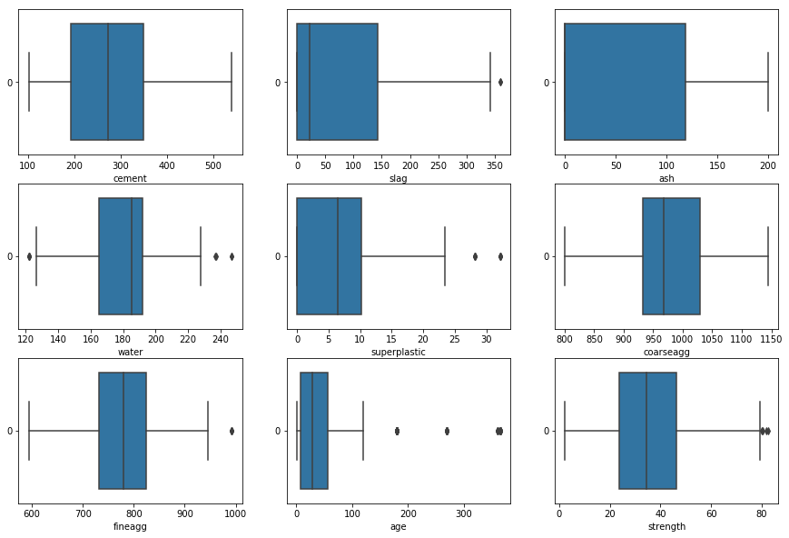

```python
#### LEts plot the box for each
plt.figure(figsize=(15,10))
pos = 1
for column in concrete_df.select_dtypes(include=[np.number]):
    plt.subplot(3, 3, pos)
    box_plot = sns.boxplot(data=concrete_df[column], orient="h")
    box_plot.set(xlabel=column)
    pos += 1
```

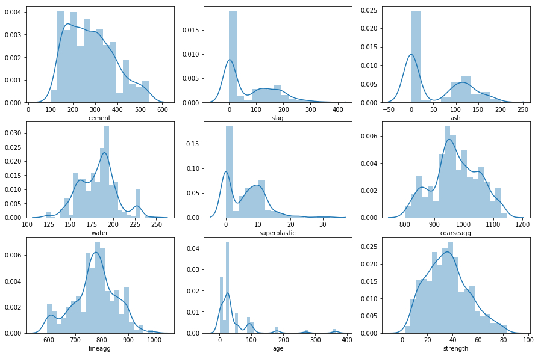

```python
#### LEts check frequsncy for each
plt.figure(figsize=(15,10))
pos = 1
for column in concrete_df.select_dtypes(include=[np.number]):
    plt.subplot(3, 3, pos)
    dist_plot=sns.distplot(concrete_df[column])
    dist_plot.set(xlabel=column)
    pos += 1
```

#### High level observations indicate

- cement -- Reasonably well balanced data
- slag -- Tail at the right .. high number of 0's
- ash -- Tail at the right ... higher number of 0's
- water -- Resonably well balanced data, but multiple peaks
- superplastic -- Again large number or 0's, Tail towards right
- coarseagg -- Reasonably well balanced data
- fineagg -- resonably well balanced data
- age -- looks skewed with right tail . Most values seem to be in 28 range (which i think is standard measurement for - compressive strength according to standards) .few outliers at the 300+ range
- strength -- seems to be resonably well balanced with little outliers

### b. Multivariate analysis

i. Bi-variate analysis between the predictor variables and between the predictor variables and target column. Comment on your findings in terms of their relationship and degree of relation if any. Presence of leverage points. Visualize the analysis using boxplots and pair plots, histograms or density curves. Select the most appropriate attributes

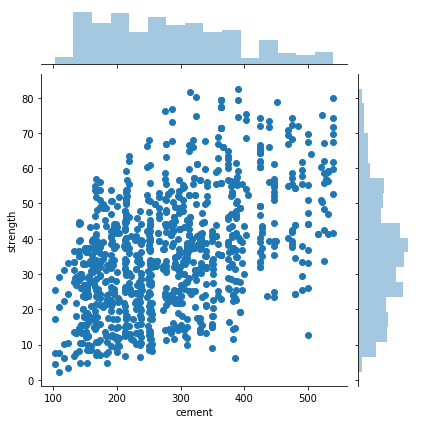

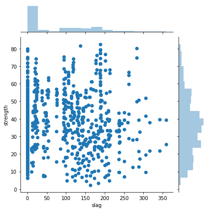

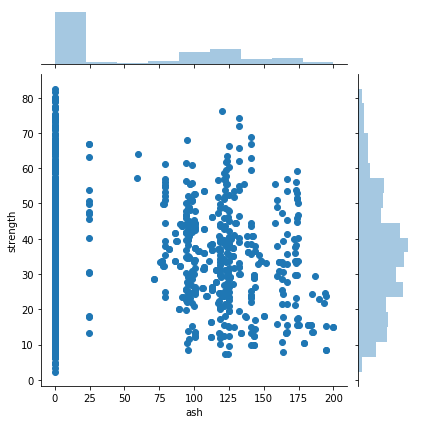

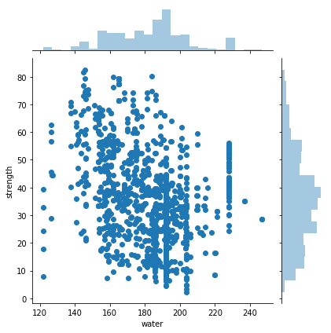

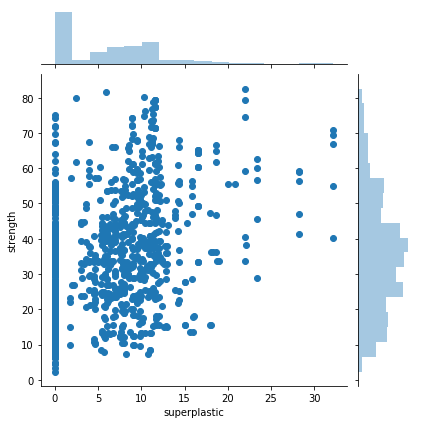

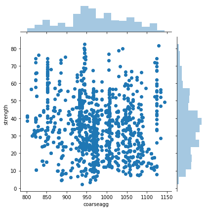

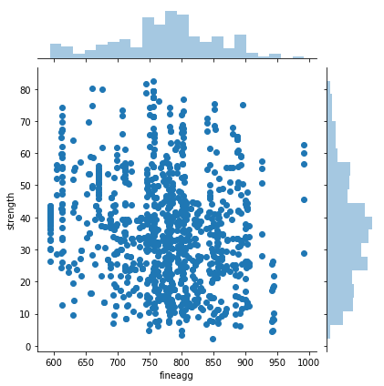

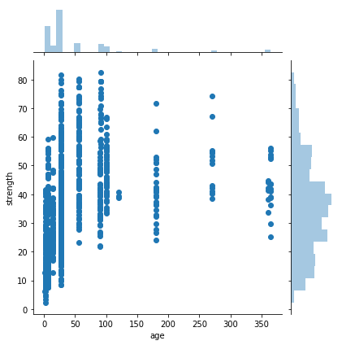

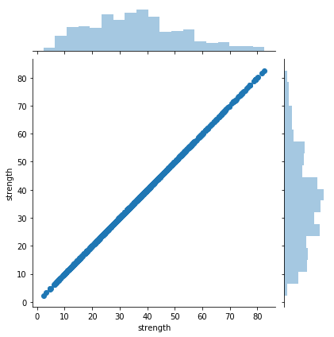

```python
#### LEts check frequsncy for each
plt.figure()
for column in concrete_df.select_dtypes(include=[np.number]):
    joint_plot = sns.jointplot(x=concrete_df[column], y=concrete_df['strength'], data=concrete_df);
```

#### OBservation on the joint plot,

- I dont see any strong co-relation of any individual variable with target except for-- cement and strength seem to weakly releated.. i do see strenth slightly increasing with increase of cement.

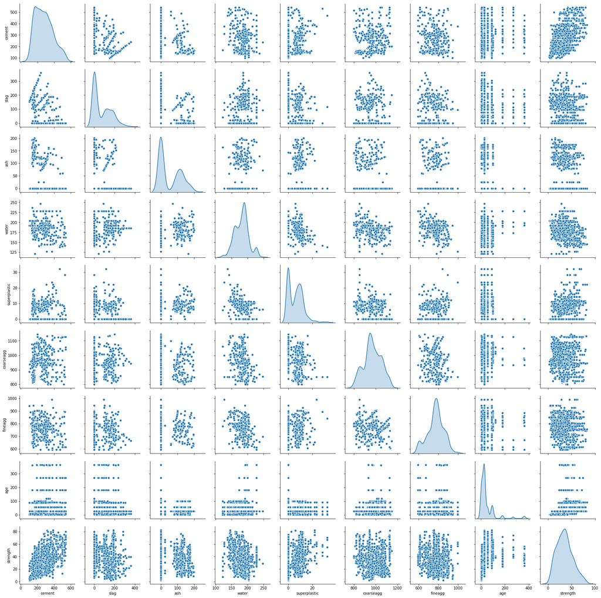

```python
#Lets pair plot.
sns.pairplot(concrete_df, diag_kind="kde")
```

#### Some weak co-relation between cement & Strength.. no other variables seem co-related. There are some indications of 2 or more gaussians for slag, ash, superplastic, age ...

I am not sure about - Presence of leverage points.. Looking at definition..

Leverage: An observation with an extreme value on a predictor variable is called a point with high leverage. Leverage is a measure of how far an observation deviates from the mean of that variable. These leverage points can have an effect on the estimate of regression coefficients.

Ref :: https://songhuiming.github.io/pages/2016/11/27/linear-regression-in-python-outliers-leverage-detect/

```python
#TODO :: To check for Presense of Leverage points.
```

### c. Strategies to address the different data challenges such as data pollution, outliers and missing values

##### Data Pollution

I dont see any explicit Data pollution (But no way to know if the high number of 0s in slag, ash, super plastic indicate polluted data. We assume all the values are practical and noted as observed)

To detect pollution, we need to examine the collection channels and the method how data enters the system.

##### Outliers

We have several outlier values in several columns. We could

1. Get rid of the rows where we have outliers (we will then lose the data -- which is not good)
2. Recalibrate the outliers on either side to 5th and 95th percentile (in this case we might corrupt the data)

I feel it is better to keep the data as is and try to fit the models and I will come back to normalizing the outliers if models are unable to converge.

##### Missing Values

I dont see any explicit missing values (NA) (But no way to know if the high number of 0s in slag, ash, super plastic indicate default value fall back)

### 2. Deliverable -2 (Feature Engineering techniques)

#### a. Identify opportunities (if any) to create a composite feature, drop a feature

```python
#Lets Normalize

from scipy.stats import zscore
concrete_df_z = concrete_df.apply(zscore)
concrete_df_z.head()
```

|  | cement | slag | ash | water | superplastic | coarseagg | fineagg | age | strength |
| --- | --- | --- | --- | --- | --- | --- | --- | --- | --- |
| 0 | -1.339017 | 1.601441 | -0.847144 | 1.027590 | -1.039143 | -0.014398 | -0.312970 | -0.279733 | -0.355018 |
| 1 | -1.074790 | -0.367541 | 1.096078 | -1.090116 | 0.769617 | 1.388141 | 0.282260 | -0.501465 | -0.737108 |
| 2 | -0.298384 | -0.856888 | 0.648965 | 0.273274 | -0.118015 | -0.206121 | 1.093371 | -0.279733 | -0.395144 |
| 3 | -0.145209 | 0.465044 | -0.847144 | 2.175461 | -1.039143 | -0.526517 | -1.292542 | -0.279733 | 0.600806 |
| 4 | -1.209776 | 1.269798 | -0.847144 | 0.549700 | 0.484905 | 0.958372 | -0.959363 | -0.279733 | -1.049727 |

### Slag and Ash seem very similarly distributed. Im wondering if its worth dropping one of them. But i feel, lets try the model first and then drop if needed

```python
# Check co-relation
corr = concrete_df_z.corr()
print (corr)
```

```
                cement      slag       ash     water  superplastic  coarseagg  \
cement        1.000000 -0.275216 -0.397467 -0.081587      0.092386  -0.109349
slag         -0.275216  1.000000 -0.323580  0.107252      0.043270  -0.283999
ash          -0.397467 -0.323580  1.000000 -0.256984      0.377503  -0.009961
water        -0.081587  0.107252 -0.256984  1.000000     -0.657533  -0.182294
superplastic  0.092386  0.043270  0.377503 -0.657533      1.000000  -0.265999
coarseagg    -0.109349 -0.283999 -0.009961 -0.182294     -0.265999   1.000000
fineagg      -0.222718 -0.281603  0.079108 -0.450661      0.222691  -0.178481
age           0.081946 -0.044246 -0.154371  0.277618     -0.192700  -0.003016
strength      0.497832  0.134829 -0.105755 -0.289633      0.366079  -0.164935

               fineagg       age  strength
cement       -0.222718  0.081946  0.497832
slag         -0.281603 -0.044246  0.134829
ash           0.079108 -0.154371 -0.105755
water        -0.450661  0.277618 -0.289633
superplastic  0.222691 -0.192700  0.366079
coarseagg    -0.178481 -0.003016 -0.164935
fineagg       1.000000 -0.156095 -0.167241
age          -0.156095  1.000000  0.328873
strength     -0.167241  0.328873  1.000000
```

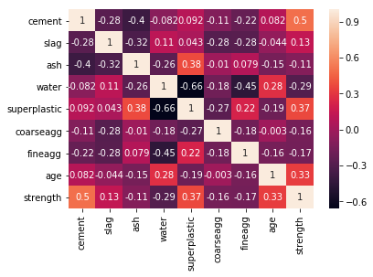

```python
# plot the heatmap
sns.heatmap(corr,
        xticklabels=corr.columns,
        yticklabels=corr.columns, annot=True)
```

#### b. Decide on complexity of the model, should it be simple linear mode in terms of parameters or would a quadratic or higher degree help

```python
## Define X and y variables
X = concrete_df_z.drop('strength', axis=1)
y = concrete_df_z['strength']
X.head()
```

|  | cement | slag | ash | water | superplastic | coarseagg | fineagg | age |
| --- | --- | --- | --- | --- | --- | --- | --- | --- |
| 0 | -1.339017 | 1.601441 | -0.847144 | 1.027590 | -1.039143 | -0.014398 | -0.312970 | -0.279733 |
| 1 | -1.074790 | -0.367541 | 1.096078 | -1.090116 | 0.769617 | 1.388141 | 0.282260 | -0.501465 |
| 2 | -0.298384 | -0.856888 | 0.648965 | 0.273274 | -0.118015 | -0.206121 | 1.093371 | -0.279733 |
| 3 | -0.145209 | 0.465044 | -0.847144 | 2.175461 | -1.039143 | -0.526517 | -1.292542 | -0.279733 |
| 4 | -1.209776 | 1.269798 | -0.847144 | 0.549700 | 0.484905 | 0.958372 | -0.959363 | -0.279733 |

```python
##Split into training and test set
from sklearn.model_selection import train_test_split

X_train, X_test, y_train, y_test = train_test_split(X, y, test_size=0.30, random_state=1)
```

```python
# Fit Simple Linear
from sklearn.linear_model import LinearRegression
from sklearn.metrics import mean_squared_error, r2_score

model = LinearRegression()
model.fit(X_train, y_train)
y_pred = model.predict(X_test)

rmse = np.sqrt(mean_squared_error(y_test,y_pred))
r2 = r2_score(y_test,y_pred)
print(rmse)
print(r2)

#Initialize Result Array for summary
result = pd.DataFrame({'Model' : ['Linear Regression'], 'RMS' : [rmse], 'r2' : [r2],
                      'Comments' : 'Low accuracy explains [r2] percent fit and high error'})
```

```
0.618177114503482
0.6339136715208273
```

```python
# Make Poly
from sklearn.preprocessing import PolynomialFeatures

polynomial_features = PolynomialFeatures(3)

X_train_poly = polynomial_features.fit_transform(X_train)
X_test_poly = polynomial_features.fit_transform(X_test)

model = LinearRegression()
model.fit(X_train_poly, y_train)
y_poly_pred = model.predict(X_test_poly)

rmse = np.sqrt(mean_squared_error(y_test,y_poly_pred))
r2 = r2_score(y_test,y_poly_pred)
print(rmse)
print(r2)

result.loc[1] = ['Linear Reg Polynomial (Deg=3)', rmse, r2, 'reasonable accuracy and low error']
```

```
0.3686311214517834
0.8698207817203698
```

### Looks like Degree 3 fitting is giving us good accuracy with lesser RMSE. I am going to keep it.

```python
X_poly = polynomial_features.fit_transform(X)
X_poly.shape
```

```
(1030, 165)
```

#### c. Explore for gaussians. If data is likely to be a mix of gaussians, explore individual clusters and present your findings in terms of the independent attributes and their suitability to predict strength

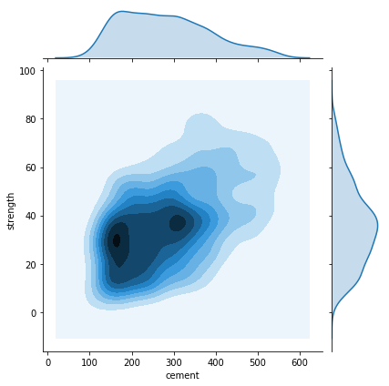

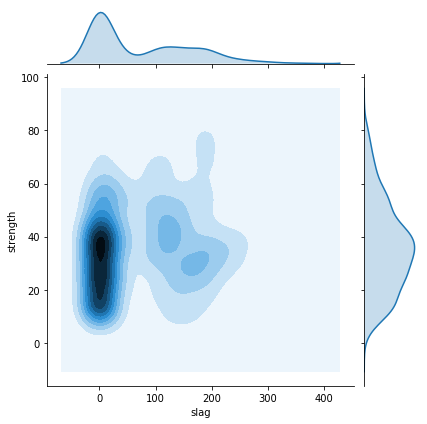

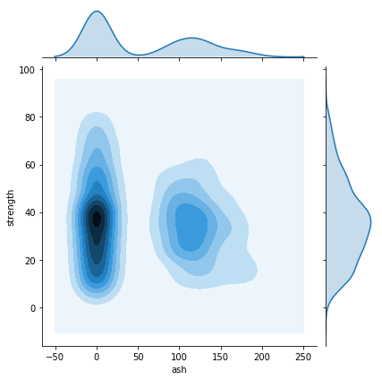

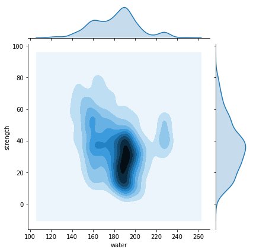

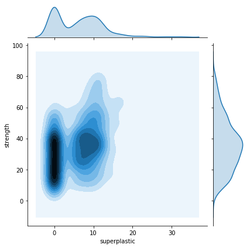

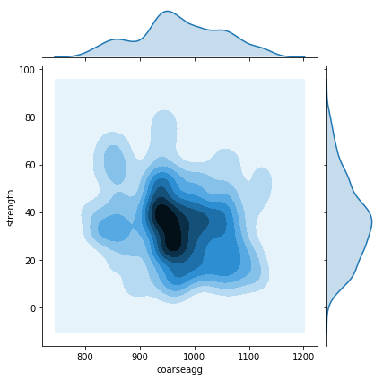

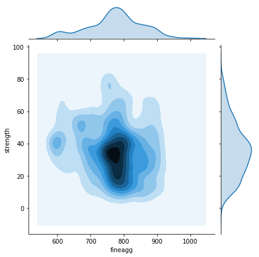

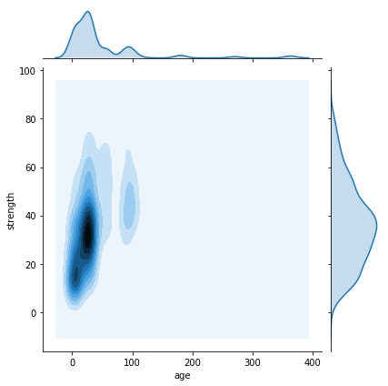

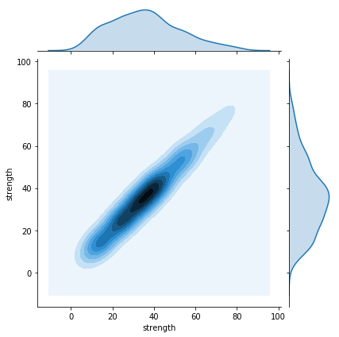

```python
#### LEts check cluster for each variable vs target
plt.figure()
for column in concrete_df.select_dtypes(include=[np.number]):
    joint_plot = sns.jointplot(x=concrete_df[column], y=concrete_df['strength'], data=concrete_df, kind='kde');
```

```python
#### generate the linkage matrix
from scipy.cluster.hierarchy import dendrogram, linkage
Z = linkage(X_poly, 'ward', metric='euclidean')
Z.shape
```

```
(1029, 4)
```

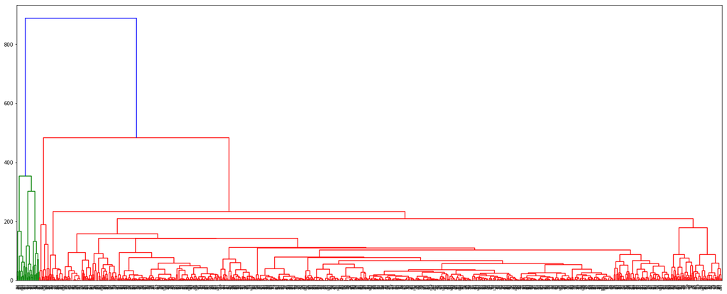

```python
plt.figure(figsize=(25, 10))
dendrogram(Z)
plt.show()
```

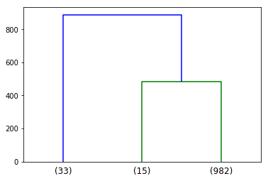

```python
dendrogram(
    Z,
    truncate_mode='lastp',  # show only the last p merged clusters
    p=3,  # show only the last p merged clusters
)
plt.show()
```

### 3. Deliverable -3 (create the model )

a. Obtain feature importance for the individual features using multiple methods and present your findings

```python
from sklearn.ensemble import ExtraTreesRegressor

# Build a forest and compute the feature importances
forest = ExtraTreesRegressor(n_estimators=250,
                              random_state=0)

forest.fit(X, y)
importances = forest.feature_importances_
std = np.std([tree.feature_importances_ for tree in forest.estimators_],
             axis=0)
indices = np.argsort(importances)[::-1]

header = list(X.columns)

# Print the feature ranking
print("Feature ranking:")

for f in range(X.shape[1]):
    print("%d. feature %d %s (%f)" % (f + 1, indices[f], header[indices[f]], importances[indices[f]]))
```

```
Feature ranking:
1. feature 7 age (0.362571)
2. feature 0 cement (0.251731)
3. feature 4 superplastic (0.093553)
4. feature 3 water (0.089943)
5. feature 1 slag (0.084447)
6. feature 6 fineagg (0.044267)
7. feature 2 ash (0.041252)
8. feature 5 coarseagg (0.032237)
```

```python
forest.fit(X_poly, y)
importances = forest.feature_importances_
std = np.std([tree.feature_importances_ for tree in forest.estimators_],
             axis=0)
indices = np.argsort(importances)[::-1]

# Print the feature ranking
print("Feature ranking:")

for f in range(X_poly.shape[1]):
    print("%d. feature %d (%f)" % (f + 1, indices[f], importances[indices[f]]))
```

```
Feature ranking:
1. feature 8 (0.123953)
2. feature 1 (0.090699)
3. feature 114 (0.050513)
4. feature 164 (0.039432)
5. feature 53 (0.036789)
6. feature 44 (0.029052)
7. feature 60 (0.028741)
8. feature 16 (0.026709)
9. feature 4 (0.024411)
10. feature 5 (0.023203)
11. feature 45 (0.017547)
12. feature 38 (0.016462)
13. feature 52 (0.013926)
14. feature 80 (0.013582)
15. feature 29 (0.013307)
16. feature 87 (0.013152)
17. feature 148 (0.012242)
18. feature 123 (0.012221)
19. feature 10 (0.011600)
20. feature 2 (0.011464)
21. feature 111 (0.011386)
22. feature 26 (0.011231)
23. feature 54 (0.010486)
24. feature 46 (0.009986)
25. feature 23 (0.009963)
26. feature 154 (0.009554)
27. feature 110 (0.008509)
28. feature 84 (0.007406)
29. feature 59 (0.007284)
30. feature 83 (0.007253)
31. feature 3 (0.007088)
32. feature 108 (0.006541)
33. feature 93 (0.006037)
34. feature 88 (0.005828)
35. feature 78 (0.005753)
36. feature 12 (0.005669)
37. feature 9 (0.005501)
38. feature 75 (0.005449)
39. feature 157 (0.005054)
```

[output cut: 111 more lines]

```
151. feature 68 (0.000953)
152. feature 104 (0.000952)
153. feature 92 (0.000928)
154. feature 106 (0.000924)
155. feature 143 (0.000905)
156. feature 79 (0.000903)
157. feature 86 (0.000881)
158. feature 107 (0.000860)
159. feature 58 (0.000851)
160. feature 51 (0.000848)
161. feature 158 (0.000813)
162. feature 72 (0.000804)
163. feature 22 (0.000780)
164. feature 97 (0.000645)
165. feature 0 (0.000000)
```

### Method 1 :: Using extra trees regressor ensemble for checking feature importance on both X and X_Poly..

for Non-Poly, the age and cement seem to be very important features

Feature ranking:

1. feature 7 age (0.362571)
2. feature 0 cement (0.251731)
3. feature 4 superplastic (0.093553)

for Poly, its difficult to see what derivative is important.. but its listed in descending order

Feature ranking:

1. feature 8 (0.123953)
2. feature 1 (0.090699)
3. feature 114 (0.050513)
4. feature 164 (0.039432)

```python
from sklearn.linear_model import LinearRegression
from sklearn.linear_model import Ridge

lr = LinearRegression()
lr.fit(X_train, y_train)
rr = Ridge(alpha=0.2) # higher the alpha value, more restriction on the coefficients; low alpha > more generalization, coefficients are barely
# restricted and in this case linear and ridge regression resembles
rr.fit(X_train, y_train)
train_score=lr.score(X_train, y_train)
test_score=lr.score(X_test, y_test)
Ridge_train_score = rr.score(X_train,y_train)
Ridge_test_score = rr.score(X_test, y_test)
coeff_used = np.sum(rr.coef_!=0)


print ("linear regression train score: ", train_score)
print ("linear regression test score: ", test_score)

print ("ridge regression train score low alpha: ", Ridge_train_score)
print ("ridge regression test score low alpha: ", Ridge_test_score)
print ("number of features used: for low alpha", coeff_used)


#print (rr.coef_)

indices = np.argsort(rr.coef_)[::-1]

header = list(X.columns)

# Print the feature ranking
print("Feature ranking low alpha ridge:")

for f in range(X.shape[1]):
    print("%d. feature %d %s (%f)" % (f + 1, indices[f], header[indices[f]], rr.coef_[indices[f]]))

rmse = mean_squared_error(y_test,rr.predict(X_test))
r2 = r2_score(y_test,rr.predict(X_test))

result.loc[2] = ['Linear Reg Ridge(alpha=0.2)', rmse, r2, 'low accuracy and high error']
```

```
linear regression train score:  0.6031487540630229
linear regression test score:  0.6339136715208273
ridge regression train score low alpha:  0.6031469778446135
ridge regression test score low alpha:  0.6339948097552128
number of features used: for low alpha 8
Feature ranking low alpha ridge:
1. feature 0 cement (0.788236)
2. feature 1 slag (0.558650)
3. feature 7 age (0.417287)
4. feature 2 ash (0.344422)
5. feature 6 fineagg (0.170675)
6. feature 4 superplastic (0.134502)
7. feature 5 coarseagg (0.109478)
8. feature 3 water (-0.134193)
```

```python
rr1 = Ridge(alpha=1) #  comparison with alpha value
rr1.fit(X_train, y_train)

Ridge_train_score1 = rr1.score(X_train,y_train)
Ridge_test_score1 = rr1.score(X_test, y_test)
coeff_used_1 = np.sum(rr1.coef_!=0)

print ("ridge regression train score high alpha: ", Ridge_train_score1)
print ("ridge regression test score high alpha: ", Ridge_test_score1)
print ("number of features used: for high alpha", coeff_used_1)

#print (rr1.coef_)

indices = np.argsort(rr1.coef_)[::-1]

header = list(X.columns)

# Print the feature ranking
print("Feature ranking high alpha ridge:")

for f in range(X.shape[1]):
    print("%d. feature %d %s (%f)" % (f + 1, indices[f], header[indices[f]], rr1.coef_[indices[f]]))

rmse = mean_squared_error(y_test,rr1.predict(X_test))
r2 = r2_score(y_test,rr1.predict(X_test))

result.loc[3] = ['Linear Reg Ridge(alpha=1)', rmse, r2, 'low accuracy and high error']
```

```
ridge regression train score high alpha:  0.6031071837335765
ridge regression test score high alpha:  0.634267851120949
number of features used: for high alpha 8
Feature ranking high alpha ridge:
1. feature 0 cement (0.774911)
2. feature 1 slag (0.545567)
3. feature 7 age (0.416096)
4. feature 2 ash (0.332698)
5. feature 6 fineagg (0.159104)
6. feature 4 superplastic (0.134552)
7. feature 5 coarseagg (0.100466)
8. feature 3 water (-0.143069)
```

```python
from sklearn.linear_model import Lasso

lasso02 = Lasso(alpha=0.02, max_iter=10e5)
lasso02.fit(X_train,y_train)
train_score02=lasso02.score(X_train,y_train)
test_score02=lasso02.score(X_test,y_test)
coeff_used02 = np.sum(lasso02.coef_!=0)
print ("training score for alpha=0.02:", train_score02 )
print ("test score for alpha =0.02: ", test_score02)
print ("number of features used: for alpha =0.02:", coeff_used02)

#print (lasso02.coef_)

print("Feature ranking low alpha lasso:")

indices = np.argsort(lasso02.coef_)[::-1]

header = list(X.columns)

for f in range(X.shape[1]):
    print("%d. feature %d %s (%f)" % (f + 1, indices[f], header[indices[f]], lasso02.coef_[indices[f]]))

rmse = mean_squared_error(y_test,lasso02.predict(X_test))
r2 = r2_score(y_test,lasso02.predict(X_test))

result.loc[4] = ['Linear Reg lasso (alpha=0.02)', rmse, r2, 'low accuracy and high error']
```

```
training score for alpha=0.02: 0.5929151394087862
test score for alpha =0.02:  0.6233525572361511
number of features used: for alpha =0.02: 7
Feature ranking low alpha lasso:
1. feature 0 cement (0.562763)
2. feature 7 age (0.375468)
3. feature 1 slag (0.334117)
4. feature 4 superplastic (0.159284)
5. feature 2 ash (0.129618)
6. feature 6 fineagg (0.000000)
7. feature 5 coarseagg (-0.000695)
8. feature 3 water (-0.230059)
```

```python
lasso2 = Lasso(alpha=0.2, max_iter=10e5)
lasso2.fit(X_train,y_train)
train_score2=lasso2.score(X_train,y_train)
test_score2=lasso2.score(X_test,y_test)
coeff_used2 = np.sum(lasso2.coef_!=0)
print ("training score for alpha=0.2:", train_score2 )
print ("test score for alpha =0.2: ", test_score2)
print ("number of features used: for alpha =0.2:", coeff_used2)

#print (lasso02.coef_)

print("Feature ranking low alpha lasso:")

indices = np.argsort(lasso2.coef_)[::-1]

header = list(X.columns)

for f in range(X.shape[1]):
    print("%d. feature %d %s (%f)" % (f + 1, indices[f], header[indices[f]], lasso2.coef_[indices[f]]))

rmse = mean_squared_error(y_test,lasso2.predict(X_test))
r2 = r2_score(y_test,lasso2.predict(X_test))

result.loc[5] = ['Linear Reg lasso(alpha=0.2)', rmse, r2, 'very low accuracy and low error']
```

```
training score for alpha=0.2: 0.3527146641539234
test score for alpha =0.2:  0.3376328449268696
number of features used: for alpha =0.2: 4
Feature ranking low alpha lasso:
1. feature 0 cement (0.279689)
2. feature 4 superplastic (0.156042)
3. feature 7 age (0.118539)
4. feature 1 slag (0.000774)
5. feature 6 fineagg (-0.000000)
6. feature 5 coarseagg (-0.000000)
7. feature 3 water (-0.000000)
8. feature 2 ash (-0.000000)
```

### Method 2. Ridge, Lasso..

Using Ridge and lasso, we can see that we get different important featuers.. But lasso accuracy for 0.2 have dropped badly., hence it might not be good idea.

```python
# Ridge Lasso on polynomial

lr = LinearRegression()
lr.fit(X_train_poly, y_train)
rr = Ridge(alpha=0.2) # higher the alpha value, more restriction on the coefficients; low alpha > more generalization, coefficients are barely
# restricted and in this case linear and ridge regression resembles
rr.fit(X_train_poly, y_train)
train_score=lr.score(X_train_poly, y_train)
test_score=lr.score(X_test_poly, y_test)
Ridge_train_score = rr.score(X_train_poly,y_train)
Ridge_test_score = rr.score(X_test_poly, y_test)
coeff_used = np.sum(rr.coef_!=0)


print ("linear regression train score: ", train_score)
print ("linear regression test score: ", test_score)

print ("ridge regression train score low alpha: ", Ridge_train_score)
print ("ridge regression test score low alpha: ", Ridge_test_score)
print ("number of features used: for low alpha", coeff_used)


#print (rr.coef_)

indices = np.argsort(rr.coef_)[::-1]

# Print the feature ranking
print("Feature ranking low alpha ridge poly input :")

for f in range(X_poly.shape[1]):
    print("%d. feature %d (%f)" % (f + 1, indices[f], rr.coef_[indices[f]]))

rmse = mean_squared_error(y_test,rr.predict(X_test_poly))
r2 = r2_score(y_test,rr.predict(X_test_poly))

result.loc[6] = ['Linear Reg ridge (poly=3)(alpha=0.2)', rmse, r2, 'High accuracy']
```

```
linear regression train score:  0.931149773364625
linear regression test score:  0.8698207817203698
ridge regression train score low alpha:  0.9290985085773573
ridge regression test score low alpha:  0.8768112408522625
number of features used: for low alpha 164
Feature ranking low alpha ridge poly input :
1. feature 8 (1.336964)
2. feature 1 (0.578506)
3. feature 104 (0.548770)
4. feature 91 (0.531450)
5. feature 85 (0.425795)
6. feature 137 (0.421876)
7. feature 96 (0.366166)
8. feature 103 (0.345514)
9. feature 2 (0.339718)
10. feature 67 (0.338748)
11. feature 88 (0.307825)
12. feature 38 (0.304222)
13. feature 158 (0.301171)
14. feature 5 (0.279709)
15. feature 65 (0.275634)
16. feature 142 (0.243780)
17. feature 150 (0.240458)
18. feature 161 (0.230357)
19. feature 73 (0.223882)
20. feature 112 (0.221803)
21. feature 89 (0.219537)
22. feature 152 (0.215595)
23. feature 83 (0.179654)
24. feature 106 (0.177062)
25. feature 24 (0.176065)
26. feature 82 (0.156473)
27. feature 116 (0.150542)
28. feature 131 (0.147132)
29. feature 6 (0.136718)
30. feature 140 (0.123606)
31. feature 97 (0.121560)
32. feature 148 (0.121194)
33. feature 3 (0.119119)
34. feature 114 (0.116295)
```

[output cut: 116 more lines]

```
151. feature 102 (-0.336780)
152. feature 154 (-0.347603)
153. feature 35 (-0.363762)
154. feature 51 (-0.372479)
155. feature 90 (-0.396364)
156. feature 18 (-0.404807)
157. feature 58 (-0.412884)
158. feature 54 (-0.425800)
159. feature 10 (-0.434166)
160. feature 22 (-0.457129)
161. feature 46 (-0.459983)
162. feature 74 (-0.523847)
163. feature 47 (-0.571859)
164. feature 64 (-0.612975)
165. feature 44 (-0.985055)
```

```python
from sklearn.linear_model import Lasso

lasso02 = Lasso(alpha=0.02, max_iter=10e5)
lasso02.fit(X_train_poly,y_train)
train_score02=lasso02.score(X_train_poly,y_train)
test_score02=lasso02.score(X_test_poly,y_test)
coeff_used02 = np.sum(lasso02.coef_!=0)
print ("training score for alpha=0.02:", train_score02 )
print ("test score for alpha =0.02: ", test_score02)
print ("number of features used: for alpha =0.02:", coeff_used02)

#print (lasso02.coef_)

print("Feature ranking low alpha lasso:")

indices = np.argsort(lasso02.coef_)[::-1]

for f in range(X_poly.shape[1]):
    print("%d. feature %d (%f)" % (f + 1, indices[f], lasso02.coef_[indices[f]]))

rmse = mean_squared_error(y_test,lasso02.predict(X_test_poly))
r2 = r2_score(y_test,lasso02.predict(X_test_poly))

result.loc[7] = ['Linear Reg ridge (poly=3)(alpha=0.02)', rmse, r2, 'good accuracy']
```

```
training score for alpha=0.02: 0.8519303418356055
test score for alpha =0.02:  0.8081549840215587
number of features used: for alpha =0.02: 45
Feature ranking low alpha lasso:
1. feature 8 (0.937952)
2. feature 1 (0.354038)
3. feature 2 (0.257308)
4. feature 5 (0.128851)
5. feature 87 (0.084940)
6. feature 60 (0.081632)
7. feature 164 (0.067365)
8. feature 157 (0.053202)
9. feature 109 (0.040725)
10. feature 45 (0.037242)
11. feature 84 (0.034857)
12. feature 134 (0.032985)
13. feature 53 (0.029781)
14. feature 81 (0.023562)
15. feature 130 (0.023288)
16. feature 150 (0.022950)
17. feature 103 (0.014113)
18. feature 114 (0.013744)
19. feature 117 (0.011001)
20. feature 30 (0.010612)
21. feature 75 (0.006692)
22. feature 104 (0.006081)
23. feature 40 (0.005497)
24. feature 66 (0.004985)
25. feature 99 (0.002385)
26. feature 65 (-0.000000)
27. feature 64 (0.000000)
28. feature 52 (0.000000)
29. feature 79 (0.000000)
30. feature 78 (0.000000)
31. feature 77 (0.000000)
32. feature 76 (-0.000000)
33. feature 74 (-0.000000)
34. feature 55 (0.000000)
35. feature 56 (0.000000)
36. feature 58 (-0.000000)
```

[output cut: 114 more lines]

```
151. feature 93 (-0.016002)
152. feature 155 (-0.018781)
153. feature 57 (-0.023661)
154. feature 48 (-0.024715)
155. feature 162 (-0.029082)
156. feature 115 (-0.029686)
157. feature 135 (-0.033877)
158. feature 49 (-0.039257)
159. feature 42 (-0.048870)
160. feature 26 (-0.050346)
161. feature 32 (-0.057543)
162. feature 54 (-0.061484)
163. feature 35 (-0.099190)
164. feature 4 (-0.269989)
165. feature 44 (-0.524158)
```

### Method 2 :: Ridge and Lasso on Poly input

Ridge ::

Feature ranking low alpha ridge poly input :

1. feature 8 (1.336964)
2. feature 1 (0.578506)
3. feature 104 (0.548770)
4. feature 91 (0.531450)
5. feature 85 (0.425795)
6. feature 137 (0.421876)

Lasso ::

1. feature 8 (0.937952)
2. feature 1 (0.354038)
3. feature 2 (0.257308)
4. feature 5 (0.128851)

### 4. Deliverable -4 (Tuning the model)

#### a. Algorithms that you think will be suitable for this project

```
[444.70744935 133.36042833  64.2101853   44.22407866  29.75890613
  23.42464226  20.9956647   18.03825802  12.25528856  10.39675275
   8.76461445   8.28113861   7.76095394   6.63974562   5.33229427
   5.12996377   4.2200942    4.02759109   3.62151946   3.33598751
   3.0154588    2.79921398   2.66954836   2.62390803   2.30515445]
[0.48590914 0.14571613 0.07015919 0.04832139 0.03251604 0.02559491
 0.02294089 0.01970948 0.01339073 0.01136    0.00957665 0.00904838
 0.00848    0.00725491 0.00582633 0.00560525 0.00461108 0.00440074
 0.00395705 0.00364506 0.00329484 0.00305856 0.00291688 0.00286701
 0.00251872]
```

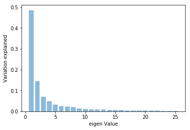

```python
### we shall try to PCA the  POLY..

from sklearn.decomposition import PCA

pca = PCA(n_components=25)
pca.fit(X_poly)

print(pca.explained_variance_)

print(pca.explained_variance_ratio_)

plt.bar(list(range(1,26)),pca.explained_variance_ratio_,alpha=0.5, align='center')
plt.ylabel('Variation explained')
plt.xlabel('eigen Value')
plt.show()
```

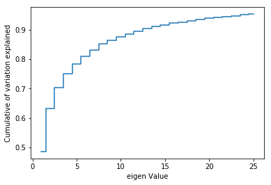

```python
plt.step(list(range(1,26)),np.cumsum(pca.explained_variance_ratio_), where='mid')
plt.ylabel('Cumulative of variation explained')
plt.xlabel('eigen Value')
plt.show()
```

```python
# 95 Per cent qantification
print(pca.explained_variance_ratio_.cumsum())
```

```
[0.48590914 0.63162527 0.70178446 0.75010586 0.78262189 0.80821681
 0.8311577  0.85086718 0.86425791 0.87561791 0.88519456 0.89424294
 0.90272293 0.90997784 0.91580417 0.92140942 0.9260205  0.93042125
 0.93437829 0.93802336 0.9413182  0.94437675 0.94729363 0.95016064
 0.95267937]
```

```python
X_poly_pca = pca.transform(X_poly)
X_poly_pca.shape
```

```
(1030, 25)
```

```python
# Lets try to fit the same poly model as earlier to check accuracy and confirm if PCA is sufficient.

X_poly_PCA_train, X_poly_PCA_test, y_train, y_test = train_test_split(X_poly_pca, y, test_size=0.30, random_state=1)


model = LinearRegression()
model.fit(X_poly_PCA_train, y_train)
y_poly_PCA_pred = model.predict(X_poly_PCA_test)

rmse = np.sqrt(mean_squared_error(y_test,y_poly_PCA_pred))
r2 = r2_score(y_test,y_poly_pred)
print(rmse) # non pca value  0.36
print(r2) #non pca value 0.87

result.loc[8] = ['Linear Reg ridge (PCA=25)', rmse, r2, 'good accuracy']
```

```
0.7241950593946174
0.8698207817203698
```

### Error has increased .. but accuracy remains same.. im perplexed..

### Lets try several models for this and check which one is better fitting.

```python
#SVM
from sklearn import svm
clf_PCA = svm.SVR(gamma=0.01,kernel='rbf',C=10)
clf_PCA.fit(X_poly_PCA_train,y_train)
pred_train = clf_PCA.predict(X_poly_PCA_train)
```

```python
clf_PCA.score(X_poly_PCA_train, y_train)
```

```
0.9228533424882449
```

```python
pred_test = clf_PCA.predict(X_poly_PCA_test)
clf_PCA.score(X_poly_PCA_test, y_test)
```

```
0.8059685590158868
```

```python
rmse = mean_squared_error(y_test,pred_test)
r2 = r2_score(y_test,pred_test)

result.loc[9] = ['SVM (PCA)(rbf kernel)', rmse, r2, 'good accuracy']
```

### Getting only 80% with test set on SVR

```python
#KNN REgression

from sklearn.neighbors import KNeighborsRegressor

clf=KNeighborsRegressor(n_neighbors=4, algorithm='auto', weights='distance')
clf.fit(X_poly_PCA_train,y_train)
y_poly_pred=clf.predict(X_poly_PCA_test)
print(mean_squared_error(y_test,y_poly_pred))
print(r2_score(y_test,y_poly_pred))


rmse = mean_squared_error(y_test,y_poly_pred)
r2 = r2_score(y_test,y_poly_pred)

result.loc[10] = ['KNN (poly=3)(PCA=25)(neighbors=4)(weights=distance)', rmse, r2, 'poor accuracy']
```

```
0.33116143086424954
0.6827530797617017
```

### Getting only 68% with test set on KNN Regressor

```python
#Random Forest Regressor
from sklearn.ensemble import RandomForestRegressor
regr = RandomForestRegressor(max_depth=25, random_state=0, n_estimators=100)
regr.fit(X_poly_PCA_train, y_train)
y_poly_pred=regr.predict(X_poly_PCA_test)
print(mean_squared_error(y_test,y_poly_pred))
print(r2_score(y_test,y_poly_pred))

rmse = mean_squared_error(y_test,y_poly_pred)
r2 = r2_score(y_test,y_poly_pred)

result.loc[11] = ['Random Forest Regressor (poly=3)(PCA=25)', rmse, r2, 'good accuracy']
```

```
0.19380305116657173
0.8143400306161147
```

### Getting 81% with Random forest regressor

```python
from xgboost import XGBRegressor
xgb_model  = XGBRegressor(max_depth=5, learning_rate=0.2, n_estimators=100, objective='reg:squarederror', booster='gbtree')
xgb_model= xgb_model.fit(X_poly_PCA_train, y_train)
pred_train = xgb_model.predict(X_poly_PCA_train)
pred_test = xgb_model.predict(X_poly_PCA_test)
```

```python
#5training score
xgb_model.score(X_poly_PCA_train , y_train)
```

```
0.9936878596927307
```

```python
#Testing score
xgb_model.score(X_poly_PCA_test , y_test)
```

```
0.8332947980636235
```

```python
rmse = mean_squared_error(y_test,pred_test)
r2 = r2_score(y_test,pred_test)

result.loc[12] = ['XG Boost Regressor (poly=3)(PCA=25)(gbtree,max_depth=5)', rmse, r2, 'good accuracy']
```

### Getting 83% test accuracy with XG Boost..for PCA input.

```python
#Just trying once with NON-PCA
xgb_model  = XGBRegressor(max_depth=5, learning_rate=0.2, n_estimators=100, objective='reg:squarederror', booster='gbtree')
xgb_model= xgb_model.fit(X_train_poly, y_train)
pred_train = xgb_model.predict(X_train_poly)
pred_test = xgb_model.predict(X_test_poly)
```

```python
xgb_model.score(X_train_poly , y_train)
```

```
0.9944024653141396
```

```python
xgb_model.score(X_test_poly , y_test)
```

```
0.8986130782407235
```

```python
rmse = mean_squared_error(y_test,pred_test)
r2 = r2_score(y_test,pred_test)

result.loc[13] = ['XG Boost Regressor (poly=3)(gbtree,max_depth=5)', rmse, r2, 'Best accuracy & least error']
```

### Also, without PCA, im able to get 89.86% score with XGBoost

#### b. Techniques employed to squeeze that extra performance out of the model without making it overfit or underfit

#### Split Train, Validate, Test

```python
X_poly_train, X_poly_test_intermediate, y_train, y_test_intermediate = train_test_split(X_poly, y, test_size=0.40, random_state=1)
```

```python
X_poly_validate, X_poly_test, y_validate, y_test = train_test_split(X_poly_test_intermediate, y_test_intermediate, test_size=0.50, random_state=1)
```

```python
X_poly_train.shape
```

```
(618, 165)
```

```python
y_train.shape
```

```
(618,)
```

```python
X_poly_validate.shape
```

```
(206, 165)
```

```python
y_validate.shape
```

```
(206,)
```

```python
X_poly_test.shape
```

```
(206, 165)
```

```python
y_test.shape
```

```
(206,)
```

```python
from sklearn.model_selection import GridSearchCV
import warnings
warnings.simplefilter(action='ignore', category=FutureWarning)
#attribution :: https://www.kaggle.com/omarito/gridsearchcv-xgbregressor-0-556-lb
# A parameter grid for XGBoost
params = {'min_child_weight':[4,5], 'gamma':[i/10.0 for i in range(3,6)],  'subsample':[i/10.0 for i in range(6,11)],
'colsample_bytree':[i/10.0 for i in range(6,11)], 'max_depth': [2,3,4], 'objective': ['reg:squarederror']}

# Initialize XGB and GridSearch
xgb = XGBRegressor(nthread=-1)

grid = GridSearchCV(xgb, params, cv=5)
grid.fit(X_poly_train, y_train)

# Print the r2 score - validate
print(r2_score(y_validate, grid.best_estimator_.predict(X_poly_validate)))
```

```
0.9108491498047762
```

```python
# Print the r2 score - test
r2 = r2_score(y_test, grid.best_estimator_.predict(X_poly_test))
rmse= np.sqrt(mean_squared_error(y_test,grid.best_estimator_.predict(X_poly_test)))

result.loc[14] = ['Grid Search CV XG Boost Regressor (poly=3)', rmse, r2, 'good accuracy']

rmse
r2
```

```
0.8837772894039021
```

```python
X_train_orig, X_test_orig, y_train_orig, y_test_orig = train_test_split(X, y, test_size=0.30, random_state=1)

# A parameter grid for XGBoost
params = {'min_child_weight':[4,5], 'gamma':[i/10.0 for i in range(3,6)],  'subsample':[i/10.0 for i in range(6,11)],
'colsample_bytree':[i/10.0 for i in range(6,11)], 'max_depth': [2,3,4,5,6], 'objective': ['reg:squarederror']}

# Initialize XGB and GridSearch
xgb = XGBRegressor(nthread=-1)

grid = GridSearchCV(xgb, params, cv=5)
grid.fit(X_train_orig, y_train_orig)
```

```
GridSearchCV(cv=5, error_score='raise-deprecating',
       estimator=XGBRegressor(base_score=0.5, booster='gbtree', colsample_bylevel=1,
       colsample_bynode=1, colsample_bytree=1, gamma=0,
       importance_type='gain', learning_rate=0.1, max_delta_step=0,
       max_depth=3, min_child_weight=1, missing=None, n_estimators=100,
       n_jobs=1, nthread=-1, objective='reg:linear', random_state=0,
       reg_alpha=0, reg_lambda=1, scale_pos_weight=1, seed=None,
       silent=None, subsample=1, verbosity=1),
       fit_params=None, iid='warn', n_jobs=None,
       param_grid={'min_child_weight': [4, 5], 'gamma': [0.3, 0.4, 0.5], 'subsample': [0.6, 0.7, 0.8, 0.9, 1.0], 'colsample_bytree': [0.6, 0.7, 0.8, 0.9, 1.0], 'max_depth': [2, 3, 4, 5, 6], 'objective': ['reg:squarederror']},
       pre_dispatch='2*n_jobs', refit=True, return_train_score='warn',
       scoring=None, verbose=0)
```

```python
# Print the r2 score - test
r2 = r2_score(y_test_orig, grid.best_estimator_.predict(X_test_orig))
rmse= np.sqrt(mean_squared_error(y_test_orig,grid.best_estimator_.predict(X_test_orig)))

print (rmse)
print (r2)

result.loc[15] = ['Grid Search CV XG Boost Regressor (original X)', rmse, r2, 'great accuracy']
```

```
0.31670244758551813
0.9039139138190395
```

### Looks like with Raw X we are getting good result with grid search .. R2 = 90% and rmse of 31%

#### c. Model performance range at 95% confidence level

```python
#ref :: https://qingkaikong.blogspot.com/2017/07/machine-learning-17-using-scikit-learn.html

from sklearn.pipeline import Pipeline
from sklearn import preprocessing

estimators = []
estimators.append(('standardize', preprocessing.StandardScaler()))
estimators.append(('xgb', XGBRegressor(objective='reg:squarederror')))
pipe = Pipeline(estimators)

pipe.fit(X_train_orig, y_train_orig)

pipe.score(X_test_orig, y_test_orig)
```

```
0.9002154875128411
```

```python
from sklearn.model_selection import cross_val_score

scores = cross_val_score(pipe, X, y, cv=5)
scores
```

```
array([0.88334076, 0.90804695, 0.88783223, 0.92308727, 0.89849302])
```

```python
print("Accuracy: %0.2f (+/- %0.2f)" % (scores.mean(), scores.std()))
```

```
Accuracy: 0.90 (+/- 0.01)
```

```python
params_grid = {'xgb__min_child_weight':[4,5], 'xgb__gamma':[i/10.0 for i in range(3,6)],  'xgb__subsample':[i/10.0 for i in range(6,11)],
'xgb__colsample_bytree':[i/10.0 for i in range(6,11)], 'xgb__max_depth': [2,3,4,5,6], 'xgb__objective': ['reg:squarederror']}

grid_search = GridSearchCV(estimator=pipe, param_grid=params_grid,n_jobs=-1, cv=5)

grid_search.fit(X_train_orig,y_train_orig)
```

```
GridSearchCV(cv=5, error_score='raise-deprecating',
       estimator=Pipeline(memory=None,
     steps=[('standardize', StandardScaler(copy=True, with_mean=True, with_std=True)), ('xgb', XGBRegressor(base_score=0.5, booster='gbtree', colsample_bylevel=1,
       colsample_bynode=1, colsample_bytree=1, gamma=0,
       importance_type='gain', learning_rate=0.1, max_delta_step=0,
       max_depth=3...lpha=0, reg_lambda=1, scale_pos_weight=1,
       seed=None, silent=None, subsample=1, verbosity=1))]),
       fit_params=None, iid='warn', n_jobs=-1,
       param_grid={'xgb__min_child_weight': [4, 5], 'xgb__gamma': [0.3, 0.4, 0.5], 'xgb__subsample': [0.6, 0.7, 0.8, 0.9, 1.0], 'xgb__colsample_bytree': [0.6, 0.7, 0.8, 0.9, 1.0], 'xgb__max_depth': [2, 3, 4, 5, 6], 'xgb__objective': ['reg:squarederror']},
       pre_dispatch='2*n_jobs', refit=True, return_train_score='warn',
       scoring=None, verbose=0)
```

```python
pipe.get_params().keys()
```

```
dict_keys(['memory', 'steps', 'standardize', 'xgb', 'standardize__copy', 'standardize__with_mean', 'standardize__with_std', 'xgb__base_score', 'xgb__booster', 'xgb__colsample_bylevel', 'xgb__colsample_bynode', 'xgb__colsample_bytree', 'xgb__gamma', 'xgb__importance_type', 'xgb__learning_rate', 'xgb_…
```

```python
grid_search.best_score_
```

```
0.9043809453859176
```

```python
gcv_scores = grid_search.cv_results_['mean_test_score']
gcv_scores_std = grid_search.cv_results_['std_test_score']

print("Accuracy: %0.2f (+/- %0.2f)" % (gcv_scores.mean(), gcv_scores.std()))
```

```
Accuracy: 0.89 (+/- 0.01)
```

## Result Summary

```python
result
```

|  | Model | RMS | r2 | Comments |
| --- | --- | --- | --- | --- |
| 0 | Linear Regression | 0.618177 | 0.633914 | Low accuracy explains [r2] percent fit and hig... |
| 1 | Linear Reg Polynomial (Deg=3) | 0.368631 | 0.869821 | reasonable accuracy and low error |
| 2 | Linear Reg Ridge(alpha=0.2) | 0.382058 | 0.633995 | low accuracy and high error |
| 3 | Linear Reg Ridge(alpha=1) | 0.381773 | 0.634268 | low accuracy and high error |
| 4 | Linear Reg lasso (alpha=0.02) | 0.393167 | 0.623353 | low accuracy and high error |
| 5 | Linear Reg lasso(alpha=0.2) | 0.691419 | 0.337633 | very low accuracy and low error |
| 6 | Linear Reg ridge (poly=3)(alpha=0.2) | 0.128592 | 0.876811 | High accuracy |
| 7 | Linear Reg ridge (poly=3)(alpha=0.02) | 0.200259 | 0.808155 | good accuracy |
| 8 | Linear Reg ridge (PCA=25) | 0.724195 | 0.869821 | good accuracy |
| 9 | SVM (PCA)(rbf kernel) | 0.202542 | 0.805969 | good accuracy |
| 10 | KNN (poly=3)(PCA=25)(neighbors=4)(weights=dist... | 0.331161 | 0.682753 | poor accuracy |
| 11 | Random Forest Regressor (poly=3)(PCA=25) | 0.193803 | 0.814340 | good accuracy |
| 12 | XG Boost Regressor (poly=3)(PCA=25)(gbtree,max... | 0.174017 | 0.833295 | good accuracy |
| 13 | XG Boost Regressor (poly=3)(gbtree,max_depth=5) | 0.105834 | 0.898613 | Best accuracy & least error |
| 14 | Grid Search CV XG Boost Regressor (poly=3) | 0.343174 | 0.883777 | good accuracy |
| 15 | Grid Search CV XG Boost Regressor (original X) | 0.316702 | 0.903914 | great accuracy |